# Characterisation of model species interactome available from primary molecular interaction databases: for paper

Vitalii Kleshchevnikov

23 November 2017

The report was published on 2017-11-23. Data used in the report was available on 2017-11-22.

### Computational analysis: code

All R code used in this analysis in deposited to a public Github repository: https://github.com/vitkl/imex_vs_uniprot

## 1. How well available interactome covers the proteome (SwissProt)

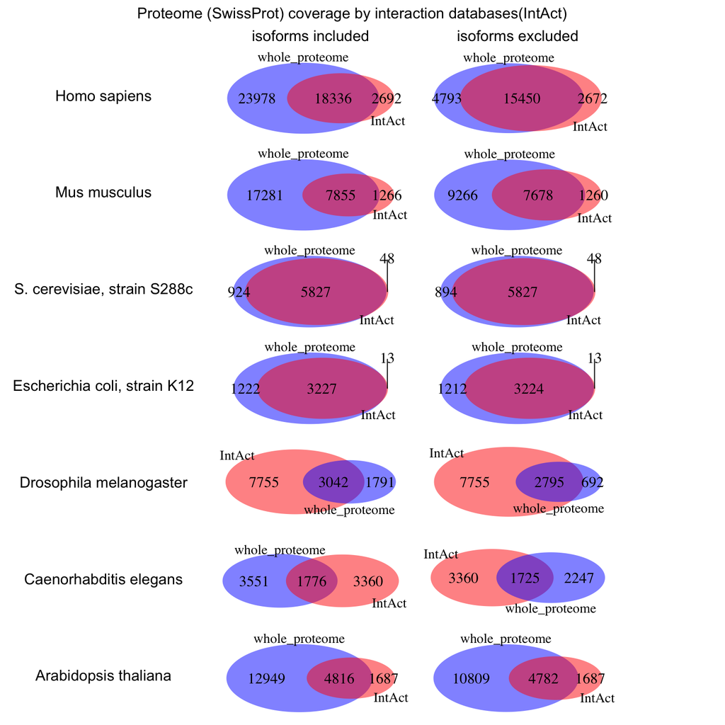

The best coverage is observed for yeast, E.coli and human. Isoform coverage is limited, but still significant for human. Red circles represent proteins which have interacting partners curated in IntAct, blue circles represent proteins in SwissProt, taking into account isoforms (left) or canonical identifiers (right).

## 2. How well available interactome covers the proteome (trEMBL)

[figure not shown]

## 3. BioGRID database (as obtained from Mentha) overlaps significantly with IMEx databases

[figure not shown]

BioGRID and IMEx share a considerable fraction of proteins with interaction data. Red circles represent proteins which have interacting partners curated in IntAct, blue circles represent proteins in SwissProt, green circles represent proteins which have interacting partners curated in BioGRID, taking into account all UniProtKB (left) or only manually reviewed SwissProt (right) proteins, only canonical identifiers considered.

## 3. Bar plot for interspecies interactions: IntAct

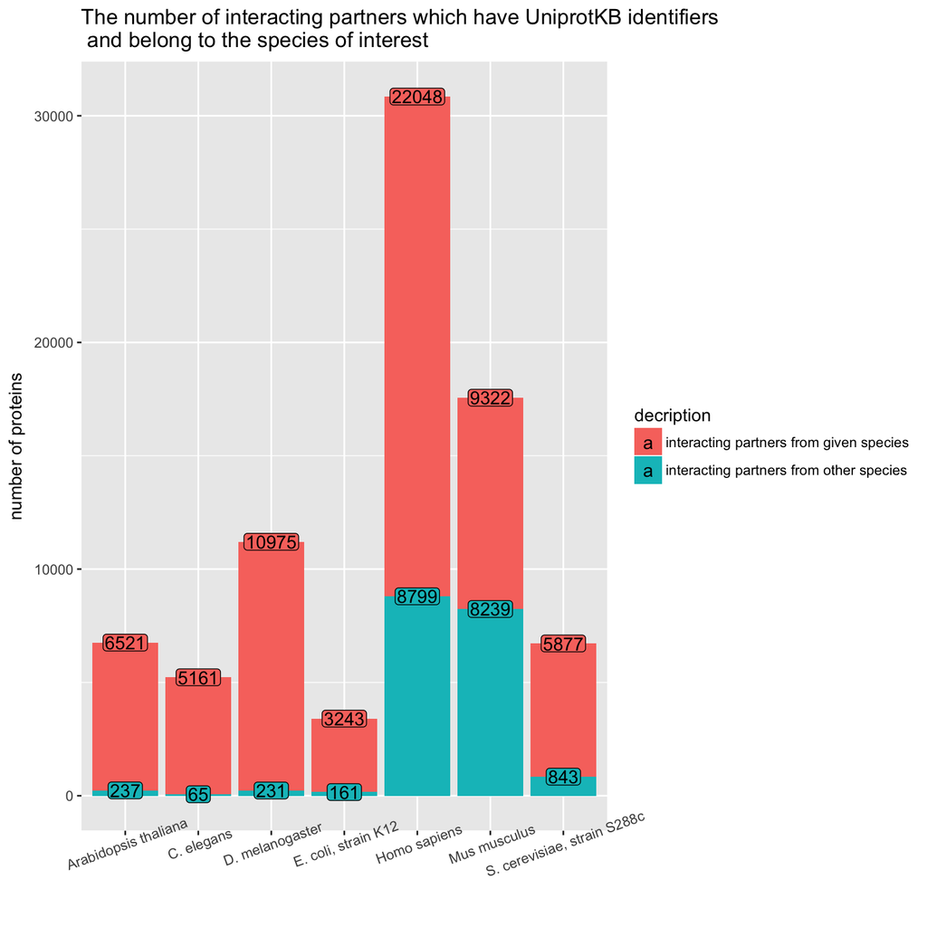

Mouse and human proteins are commonly combined for interaction experiments. Red bar shows the number of proteins from a given species, blue bar shows the number of proteins from another species. Red group proteins form interactions both with red and blue group proteins, blue group proteins form interactions only with red group proteins

Surprisingly, 19941 interactions between mouse and human proteins were discovered in human rather than mouse cells (only 1511) suggesting that researchers use mouse rather than human proteins as baits (1285 mouse baits total, 5704 human preys total, including isoforms, from 577 publications) to find interactions directly relevant to human interactome research, including human disease.

We have performed Gene Ontology enrichment analysis of proteins with no available interactions as compared to whole proteome (SwissProt protein list). We have looked at overrepresented biological processes, molecular fuctions and cellular compartment localisation of proteins. Here only overrepresented biological processes are shown.

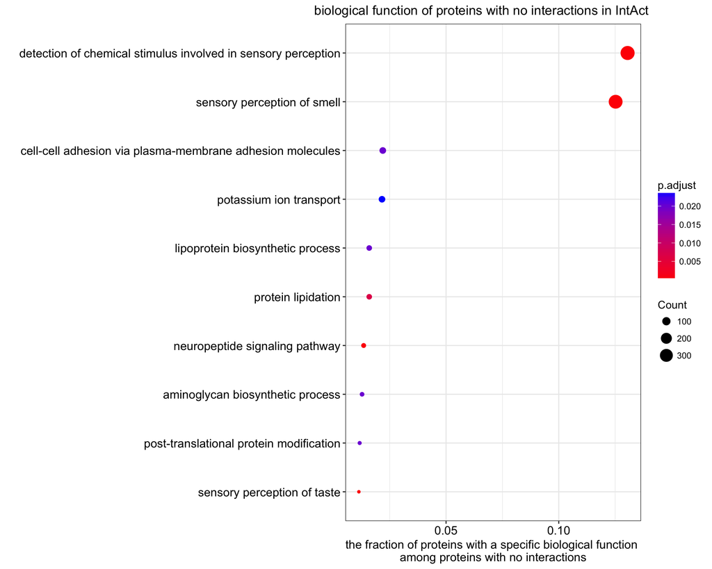

Overrepresented biological processes. The size of the dot shows the number of proteins of that category in the dataset (proteins without interaction), x-axis represents the fraction of proteins of that category in the dataset. Colour shows the probability of that overlap occurring by chance.

### Human proteins with no available interactions are on average shorter than the proteins with interactions available

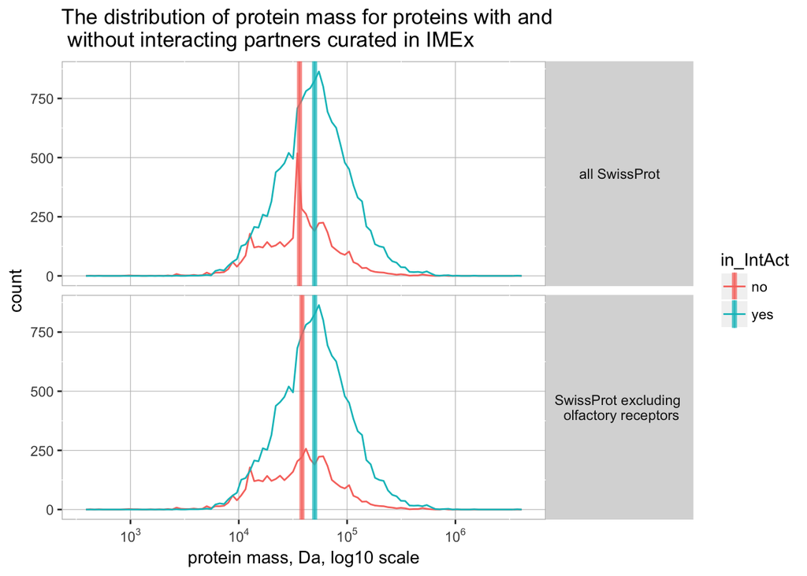

### Wilcox test for difference in distribution means

This difference in protein mass between proteins present and absent in the interactome is highly unlikely to occur by chance (Wilcox rank test (Mass, Da, 95% confidence interval: -13200, -11300, p-value: 3.92e-144) and Student t-test(log10 of Mass, Da, 95% confidence interval: -0.157, -0.135, p-value: 4.31e-146) on the whole population of proteins. The removal of 416 olfactory receptors, evidently, does not change this trend (Wilcox rank test on Mass, Da, 95% confidence interval: -13100, -11000, p-value: 2.94e-123).

## ##3. Bar plot for interspecies interactions: BioGrid from Mentha

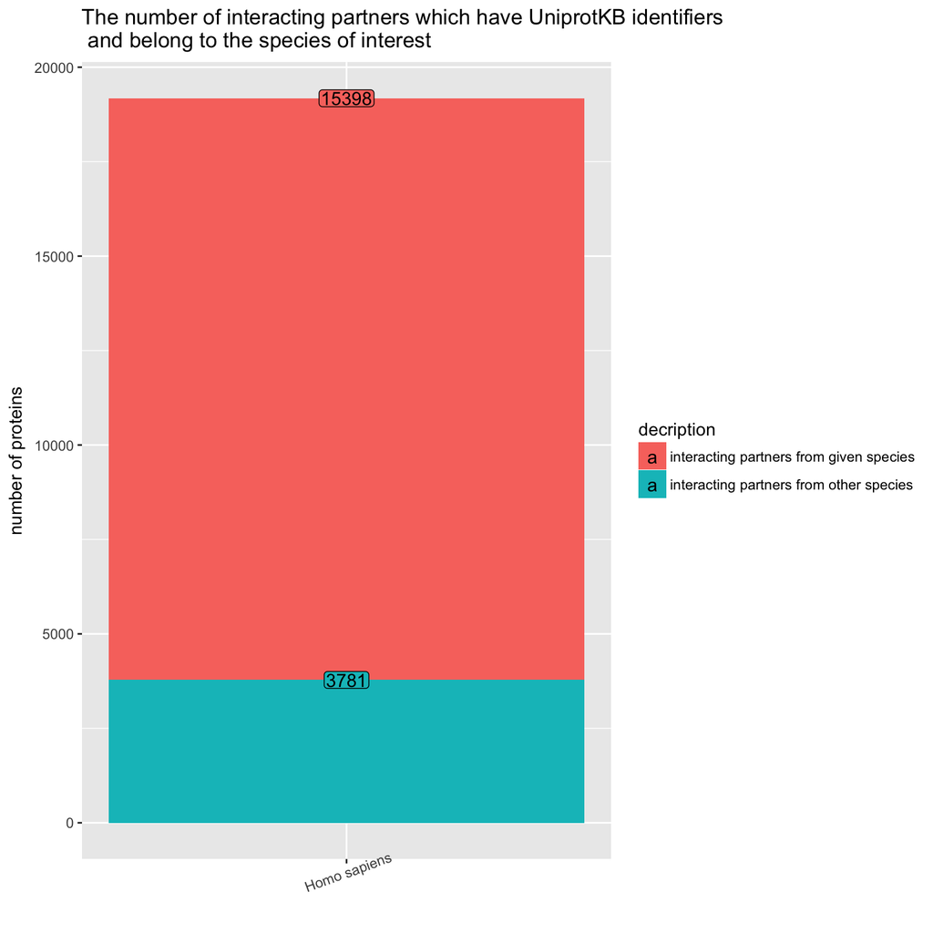

Supplementary figure 2. The number of interacting proteins from given species or the other species in BioGRID. Red bar shows the number of proteins from a given species, blue bar shows the number of proteins from another species. Red group proteins form interactions both with red and blue group proteins, blue group proteins form interactions only with red group proteins.